# Avaliação 3 - Valor: 34 pontos

Introdução à Ciência de Dados - 2025  
Bacharelado em Administração

Autores

Johnny Tobias

Kelry Fernanda

Marlon Victor

Paula Mota

Data de Publicação

9 de julho de 2025

## Questão 1

### Inferência sobre Proporções Populacionais

**a)**

```r
# Dados da pesquisa
cat_clientes_A <- 273
cat_satisf_A <- 350

cat_clientes_B <- 198
cat_satisf_B <- 290
```

```r
# Estimativa pontual da proporção de clientes satisfeitos do grupo A
prop_a <- cat_clientes_A / cat_satisf_A
prop_a
```

```
[1] 0.78
```

```r
# Estimativa pontual da proporção de clientes satisfeitos do grupo B
prop_b <- cat_clientes_B / cat_satisf_B
prop_b
```

```
[1] 0.683
```

```r
# Estimativa pontual da diferença entre as proporções
# Exibe a diferença entre eles
diferenca_observada <- prop_b - prop_a
diferenca_observada
```

```
[1] -0.0972
```

**b)** b) Por que em uma análise estatisticamente fundamentada, é incorreto reportar somente estimativas pontuais dos parâmetros da população?

Porque elas não fornecem nenhuma informação sobre a incerteza da estimativa e a precisão. A estimativa pontual pode ser o nosso melhor “chute” para o valores de um parâmetro populacional com base na amostragem quantificando o as incertezas sobre ele. E para uma análise mais detalhada e útil essa informação sobre a incerteza não pode faltar.

**c)**

```r
# Intervalo de confiança para a diferença entre proporções
resultado <- prop.test(x = c(cat_clientes_B, cat_clientes_A),
                       n = c(cat_satisf_B, cat_satisf_A),
                       conf.level = 0.95)

# Exibir resultado completo
resultado
```

```
    2-sample test for equality of proportions with continuity correction

data:  c(cat_clientes_B, cat_clientes_A) out of c(cat_satisf_B, cat_satisf_A)
X-squared = 7, df = 1, p-value = 0.007
alternative hypothesis: two.sided
95 percent confidence interval:
 -0.1693 -0.0251
sample estimates:
prop 1 prop 2
 0.683  0.780
```

**e.1)**

$$\begin{cases}
H_0: p_A\le 0.70\\
H_A: p_A > 0.70
\end{cases}$$

**e.2)**

```r
# Teste de hipótese unilateral para proporção da Categoria A

# Intervalo de confiança para a diferença entre proporções
resultado_teste_A <- prop.test(x = cat_clientes_A,
                               n = cat_satisf_A,
                               p = 0.70,
                               alternative = "greater",
                               conf.level = 0.95)
# Exibir resultado completo
resultado_teste_A
```

```
    1-sample proportions test with continuity correction

data:  cat_clientes_A out of cat_satisf_A, null probability 0.7
X-squared = 10, df = 1, p-value = 0.0007
alternative hypothesis: true p is greater than 0.7
95 percent confidence interval:
 0.74 1.00
sample estimates:
   p
0.78
```

**e.3)**

O teste de hipótese resultou em um valor-p de 0.00067 para a proporção de clientes satisfeitos na categoria A. Considerando que um nível de significância alpha seja = 0.05, podemos observar que o valor-p é menor que alpha. E com base nessas observações, rejeitamos a hipótese nula. Isso quer dizer que há evidências estatisticamente significativa com 95% de confiança para concluir que a proporção de clientes satisfeitos na categoria A é bem maior que 70%.

## Questão 2

### Inferência sobre Médias Populacionais

```r
# Cria a data.frame dados_entrega
dados_entrega <- data.frame(
  tempo = c(
    1.9908307, 3.7595980, 3.9207872, 1.9499968, 2.5570788, 2.9083451,
    3.8215787, 3.4254931, 4.1066170, 3.7159112, 2.3757705, 4.3799877,
    4.0898537, 4.6885358, 1.9032753, 4.9526208, 4.7632426, 3.5487350,
    5.2520306, 4.5840950, 2.7728566, 1.6544221, 1.9158527, 3.3874123,
    3.1677474, 4.2208561, 2.7834305, 2.9044544, 4.5360855, 2.2195599,
    2.7240852, 2.6655864, 1.4009759, 3.4665378, 3.3535627, 4.6972176,
    1.9733366, 2.5457229, 2.2336230, 2.6573906, 2.6681639, 3.1323411,
    2.4254247, 2.7917952, 4.9867621, 2.8329370, 2.8299644, 3.5470596,
    1.4070574, 3.1499424, 1.9685541, 2.4178228, 3.4466604, 3.6865291,
    3.3801921, 3.5045991, 2.2455080, 4.4135944, 3.2958687, 3.3348655,
    0.2198195, 1.6197339, 2.4793752, 3.6855232, 2.6521006, 4.5120387,
    4.4196294, 1.1254838, 2.1009464, 1.8516211, 2.5130132, 2.6551619,
    0.8074057, 4.2885169, 2.6779839
  ),
  parceiro = c(
    rep("Atual", 35),
    rep("Novo", 40)
  )
)
```

**a)**

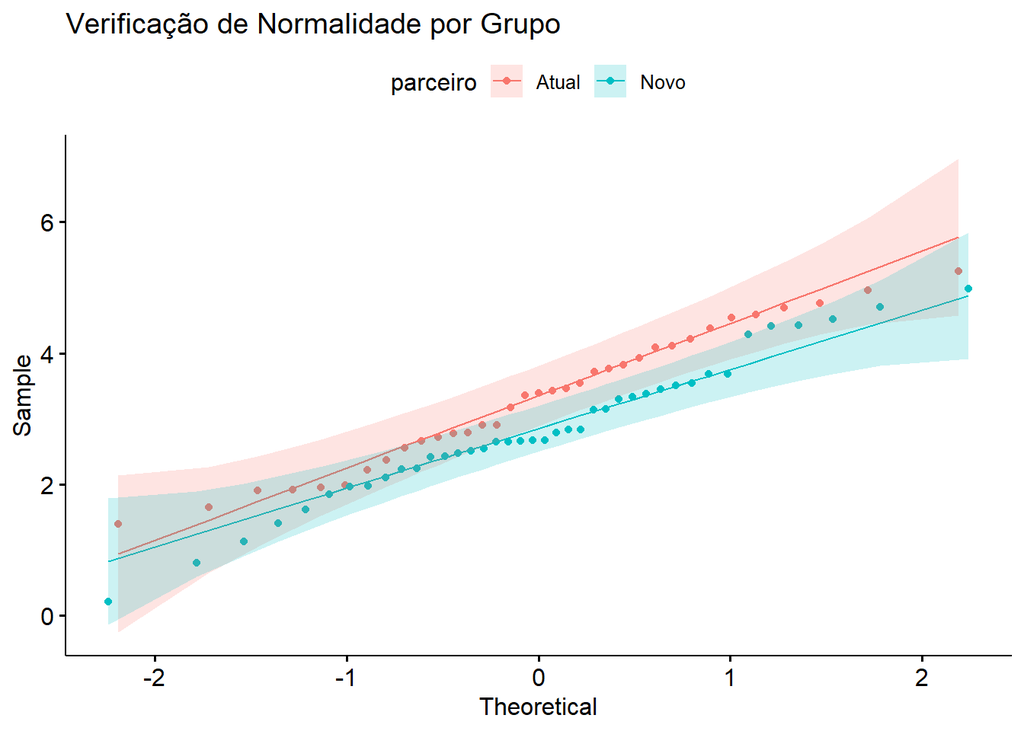

```r
# Gráfico quantile-quantile para verificar normalidade dos dados
ggqqplot(dados_entrega, x = "tempo", color = "parceiro") +
  labs(title = "Verificação de Normalidade por Grupo")
```

Como estão perto da linha teórica, isso indica que os tempos de entrega seguem aproximadamente uma distribuição normal. ja o desvio patrao tem uma pequena anormalidade mas é normal pode ser um atraso na entrega ou um adiantamento.

**b)**

```r
# Estimativa por intervalo de confiança para a diferença entre médias
resultado_ttest <- t.test(tempo ~ parceiro,
                          data = dados_entrega,
                          conf.level = 0.95)
# mostra o resultado
resultado_ttest
```

```
    Welch Two Sample t-test

data:  tempo by parceiro
t = 2, df = 72, p-value = 0.05
alternative hypothesis: true difference in means between group Atual and group Novo is not equal to 0
95 percent confidence interval:
 -0.000512  0.962466
sample estimates:
mean in group Atual  mean in group Novo
               3.31                2.83
```

**c)**

```r
# Definindo uma variavel para a media atual e media novo
media_atual <- resultado_ttest$estimate[1]
media_novo  <- resultado_ttest$estimate[2]

# Diferença estimada entre as medias
diferenca_estimada <- media_atual - media_novo

# mostrando o resultado da diferença estimada.
diferenca_estimada
```

```
mean in group Atual
              0.481
```

Olhando apenas na estimativa pontual da diferença média, o parceiro Atual parece ter maiores tempos médios de entrega

**d)**

O intervalo de confiança de 95% para a diferença das médias -0.0005122, 0.9624656, podemos perceber que o intervalo inclui o valor zero. A inclusão do zero no intervalo de confiança implica que uma diferença de zero (ou seja, não existe nenhuma diferença real entre os tempos médios populacionais) é um valor compreensível, de acordo com os dados observados. Contudo, não há base estatística suficiente para concluirmos que há uma diferença significativa nos tempos médios de entrega entre os dois parceiros.